# Pre-Registration and the Pre-Analysis Plan

Session 7

2026-10-13

## Fix the analysis before the data exist

- A p-value or a 95% interval describes a **procedure**: what would happen if the study ran again.
- That procedure has to exist before the data do.
  - Chosen afterwards, it reflects the data you happened to get.
- Deployment is the rerun that matters: real users, on the real task.
- A pre-analysis plan (PAP) writes the procedure down and files it publicly with a timestamp.
- It also records what everyone involved agreed to study and report.

Your PAP is the procedure your final report’s numbers describe.

# Why pre-registration exists

## Why write the analysis down first?

Many published findings shrink or vanish when someone checks them again.

- Which results never reach print?
- Does the answer depend on who analyzes the data?
- Can an honest analyst still fool themselves?

## Null results go in the file drawer

- **Franco et al.:** 221 survey experiments run through TESS, a shared NSF-funded platform.
  - Every study was fielded, so the full population of results is known.
- Strong results were **40 points** more likely to be published than null results.
- They were **60 points** more likely to be written up at all.

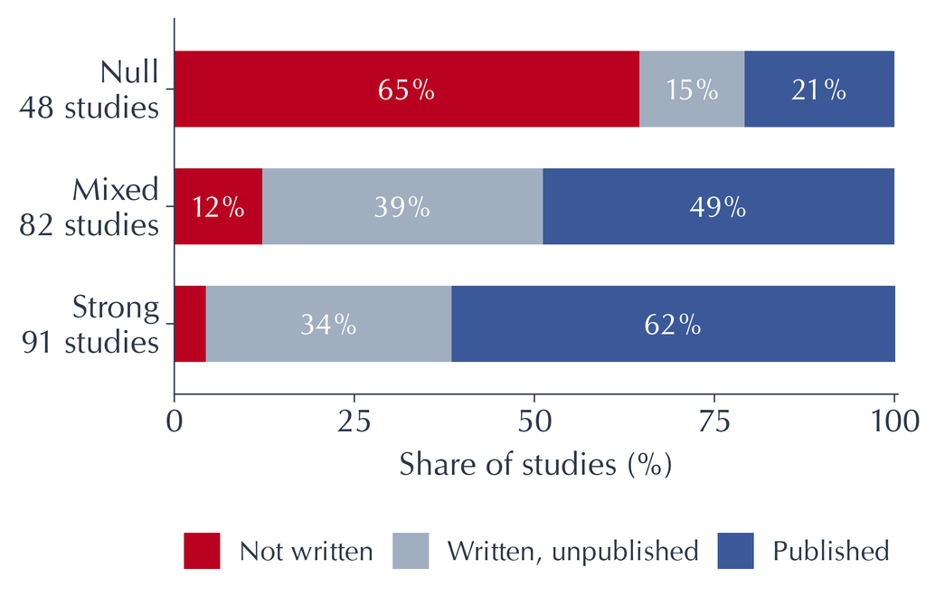

- Each published estimate can be honest. The published *record* still overstates effects.
- A registry makes the denominator visible: every study that was started.

[Franco, Malhotra & Simonovits (2014), *Publication Bias in the Social Sciences: Unlocking the File Drawer*, Science 345(6203).](https://doi.org/10.1126/science.1255484)

## Same data, different answers

- **Huntington-Klein et al.:** 146 teams estimated the effect of DACA on full-time work three times, with more fixed each time.
- Task 2 spread wider than Task 1 because teams did not follow the shared design exactly.

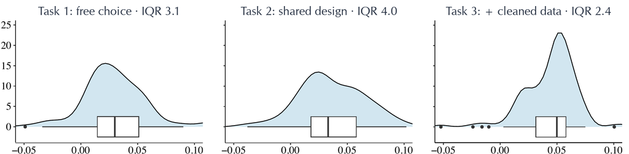

- The analyst’s choices are a source of variation that no standard error counts.

[Huntington-Klein, Portner, McCarthy & The Many Economists Collaborative on Researcher Variation (2025), *The Sources of Researcher Variation in Economics*, NBER WP 33729; forthcoming in JEL. Adapted from Figure 1: each team’s estimate, box = interquartile range in points.](https://www.nber.org/papers/w33729)

## Medicine registered trials first

- Selectively published drug trials led to:
  - **2000:** ClinicalTrials.gov opens.
  - **2005:** ICMJE journals require registration before enrollment.
  - **2007:** FDAAA makes registration and results reporting law in the US.
- **Kaplan & Irvin:** large NHLBI trials, 1970–2012. From 2000 the primary outcome had to be registered.
- **2012–13:** Casey, Glennerster & Miguel bring PAPs to economics. The AEA and EGAP registries open.

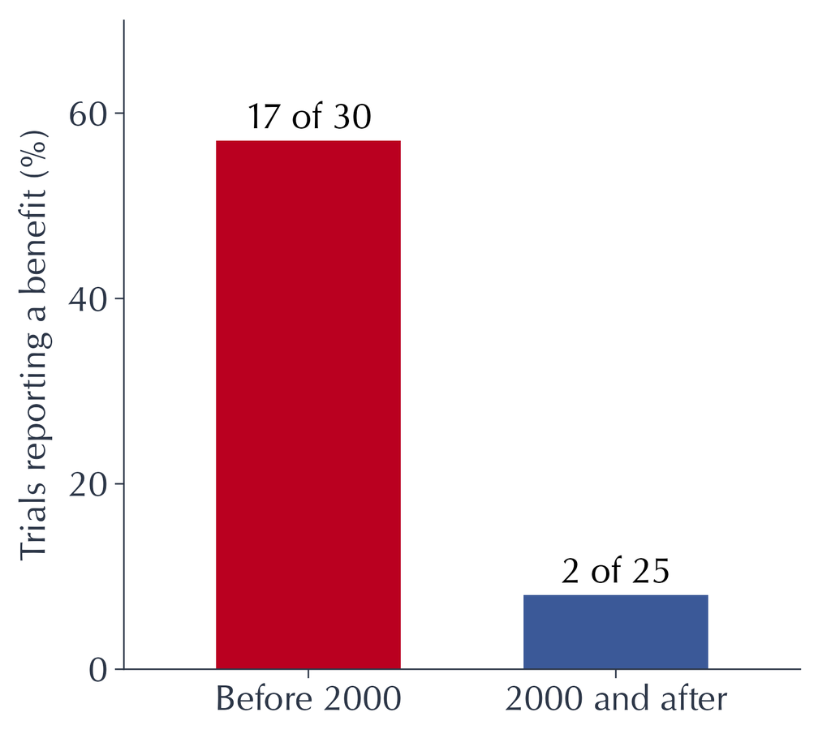

[Kaplan & Irvin (2015), *Likelihood of Null Effects of Large NHLBI Clinical Trials Has Increased over Time*, PLoS ONE 10(8).](https://doi.org/10.1371/journal.pone.0132382)

[Casey, Glennerster & Miguel (2012), *Reshaping Institutions: Evidence on Aid Impacts Using a Preanalysis Plan*, QJE 127(4).](https://doi.org/10.1093/qje/qje027)

## One honest analyst can still find false positives

- **Simmons et al.:** simulated studies with no true effect, and four choices left open:
  - which of two correlated outcomes to report
  - whether to add 10 subjects per condition after a first test
  - whether to control for gender or its interaction with treatment
  - whether to drop one of three conditions.
- Making these choices after seeing the data raises the nominal 5% false-positive rate to **61%**.
- **Gelman & Loken:** the analyst can run just one test and still inflate it.
  - A different sample would have led to a different, equally reasonable test.
  - They call this the *garden of forking paths*.

A plan fixes the test before the data arrive, so the reported p-value means what it claims.

[Simmons, Nelson & Simonsohn (2011), *False-Positive Psychology*, Psychological Science 22(11).](https://doi.org/10.1177/0956797611417632)

[Gelman & Loken (2014), *The Statistical Crisis in Science*, American Scientist 102(6).](https://sites.stat.columbia.edu/gelman/research/published/ForkingPaths.pdf)

## Forking paths in AI evaluation

- An AI evaluator has many easy-to-try forks in the path:
  - the prompt template and system prompt
  - random seeds and the number of runs
  - temperature and other decoding settings
  - the judge model, its prompt, and its rubric
  - which questions or topics count
  - which model snapshot to compare against.
- **Singh et al.:** Chatbot Arena let providers test variants privately and publish only the best.
  - Meta tested **27** private variants before the Llama 4 release.
  - The public score is the maximum of many noisy draws.

[Singh et al. (2025), *The Leaderboard Illusion*, arXiv:2504.20879.](https://arxiv.org/abs/2504.20879)

## Summary: why pre-registration exists

- **Franco et al.:** null results go unpublished. A registry shows every study started.
- **Huntington-Klein et al.:** analysts disagree by more than their standard errors.
- **Simmons et al., Gelman & Loken:** flexible analysis turns 5% false positives into 61%, with no fishing needed.
- **Singh et al.:** a published Arena score is the best of many private variants.

# Uncertainty assumes a fixed procedure

## What does a 95% interval promise?

Every error bar promises something about what a rerun of the study would show.

- Does that promise survive choosing the analysis after seeing the results?
- What does it mean once the system is deployed?
- How can you explore freely and still keep it?

## Coverage is a property of the whole procedure

- **Lecture 06:** a data set $D$ comes from the design; an interval $\operatorname{CI}(D)$ is a fixed function of it.

$$\text{coverage}=\Pr_{D}\big(\tau\in\operatorname{CI}(D)\big).$$

- The probability is over reruns of the design. The function $\operatorname{CI}$ stays the same in every rerun.
- Now try $k$ defensible analyses $j=1,\dots,k$ and report the one with the smallest p-value:

$$\hat\jmath(D)=\arg\min_{j}\,p_j(D),\qquad \text{reported interval}=\operatorname{CI}_{\hat\jmath(D)}(D).$$

- The choice of analysis now depends on $D$. Each $\operatorname{CI}_j$ covers 95%; the reported one covers less.
- If the $k$ tests were independent and $\tau=0$: $\Pr\big(\min_j p_j<0.05\big)=1-0.95^k$.

## Simulation: reporting the best of k analyses

- **Running example (lecture 06):** an LLM tutor answers 100 course questions. Retrieval over course materials is switched on for a random 50.
- Each answer is scored 0–100. Questions vary in difficulty, a pretest predicts it, and they fall into 4 topics.
- **16 analyses:** 4 covariate sets (none, pretest, topic, both) × all questions or one topic dropped.

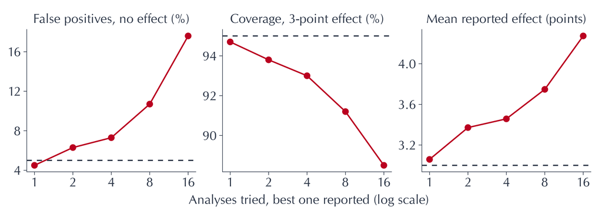

- Every analysis is unbiased on its own. Picking the best of 16 gives 18% false positives and 89% coverage, and inflates the effect from 3 to 4.3 points.

## Reporting the largest estimate biases it

- The problem reaches past intervals that fail to cover.
- Take $k$ independent estimates of one effect, each unbiased: $\operatorname{E}[\hat\tau_j]=\tau$.
- An evaluator who hopes for a large effect reports the largest one:

$$\operatorname{E}\big[\max_j\hat\tau_j\big]>\tau.$$

- With normal estimates and standard error $s$: $\operatorname{E}[\max_j\hat\tau_j]=\tau+c_k\,s$.
  - $c_k$ is the expected maximum of $k$ standard normals: $c_2=0.56$, $c_4=1.03$, $c_{16}=1.77$, $c_{27}=2.00$.
- Hoping for a small number (error rate, cost, latency) and reporting the minimum biases it downward by the same amount.
- If Meta’s 27 private Arena variants were equally good, the published best would sit about 2 standard errors above all of them.

## Deployment is the rerun that matters

- **Lecture 06, Recht:** a benchmark’s questions are fixed, so its error bar describes an imagined resampling.
  - For a benchmark run as a shared competition, that critique holds.
- Good evaluations informs a deployment decision
  - With new users, new questions, and new runs: a fresh draw.
- An analysis picked for its result fits the noise in this draw.
  - Deployment brings new noise, and performance falls back toward $\tau$.
  - The expected drop is the selection bias from the previous slide.
- Pre-registration fixes the procedure,: the reported interval describes the fresh draw.
  - How close does the evaluation’s questions and users match deployment’s?
- A holdout on the leaderboard is better than nothing (e.g. Kaggle private holdouts)
  - Stops *direct* selection on outcomes, but still admits forking paths

[Recht (2025), *Standard error of what now?*, arg min.](https://www.argmin.net/p/standard-error-of-what-now)

## A written plan defines the rerun

- A specified procedure is something another team can run again and compare.
- Model-only evaluations are cheap to rerun. Use that:
1. **Explore** on a development split: a set of seeds, a subset of questions, a pilot.
   - Try prompts, judges, and estimators freely.
2. **Write the PAP** from what you learned. Fix one analysis.
3. **Confirm** on a fresh run: new seeds, held-out questions, the registered analysis.
- The exploration is reported too, labeled as exploratory.
- Only the confirmation run carries the 95% guarantee.

## Summary: uncertainty assumes a fixed procedure

- Coverage belongs to a procedure fixed before $D$. Choosing $\hat\jmath(D)$ after seeing $D$ breaks it.
- Best of 16 in the running example: 18% false positives, 89% coverage.
- Reporting $\max_j\hat\tau_j$ overstates $\tau$ by $c_k\,s$.
- Deployment is a fresh draw, so a selected result falls back toward $\tau$.
- A written plan can be rerun: explore, register, then confirm on fresh data.

# What goes in a pre-analysis plan

## What does a plan contain?

A plan is a document several people sign, and the final report is checked against it.

- What has to be written down?
- How can you test a plan before any data exist?
- What happens when the study departs from it?

## A plan is also an agreement

- When parties with different interests evaluate together, the plan is their contract, signed before anyone knows the result.
- **US2020:** Meta and outside academics ran a set of experiments on Facebook and Instagram around the 2020 US election.
  - Each plan defined the constructs in advance, such as polarization and political knowledge.
  - It also fixed the measure of each construct and the test applied to it.
  - Where the two sides disagreed on a definition, they rewrote it until both could sign.
- The same contract settles disputes in AI evaluation:
  - **Vendor and buyer:** which tasks, which baseline, and what score counts as passing.
  - **Lab and regulator:** which harms are measured, and the threshold for release.
  - **Developer and outside auditor:** which snapshot, what access, and what gets published.

[Dimmery (2025), *What was US2020?*, ddimmery.com.](https://ddimmery.com/posts/what-was-us2020/)

## MIDA: a PAP declares the whole design

- **M**odel: how the data arise.
  - Difficulty varies (SD 8).
  - Runs are noisy (SD 6).
  - A pretest predicts difficulty.
- **I**nquiry: what you want to learn.
  - Average effect of retrieval.
  - On the 0–100 score.
  - Over these 100 questions.
- **D**ata strategy: how data are collected.
  - 100 questions.
  - Retrieval for 50, complete random.
  - One run each.
- **A**nswer strategy: how data become an answer.
  - Lin estimator with the pretest.
  - HC2 standard error.
  - 95% interval.

[Blair, Coppock & Humphreys (2023), *Research Design in the Social Sciences*, Princeton University Press, ch. 21.](https://book.declaredesign.org/lifecycle/planning.html)

## Declare the design in code

```r
design <-
  declare_model(N = 100, pretest = rnorm(N), e = rnorm(N, sd = 6),
                a = 8 * (sqrt(.6) * pretest + sqrt(.4) * rnorm(N)),
                potential_outcomes(Y ~ 50 + a + e + 3 * Z)) +
  declare_inquiry(ATE = mean(Y_Z_1 - Y_Z_0)) +
  declare_assignment(Z = complete_ra(N)) +
  declare_measurement(Y = reveal_outcomes(Y ~ Z)) +
  declare_estimator(Y ~ Z, covariates = ~ pretest, .method = lm_lin,
                    inquiry = "ATE", label = "Lin, pretest") +
  declare_estimator(Y ~ Z, .method = difference_in_means,
                    inquiry = "ATE", label = "Difference in means")
```

- Each `declare_` step is one MIDA element. The model encodes your assumptions about how the study will go.
- The design object can draw fake data from those assumptions and run the registered estimators on it.

## The mock analysis is your results section

- `run_design(design)` draws one data set from your assumptions and runs the registered analysis. The output is the **table and figure the paper will print**.

Table 1. Effect of retrieval (simulated data)

| Estimator | Estimate | SE | CI |
| --- | --- | --- | --- |
| Lin, pretest | 1.6 | 1.4 | [-1.1, 4.4] |
| Difference in means | 0.7 | 1.8 | [-2.8, 4.2] |

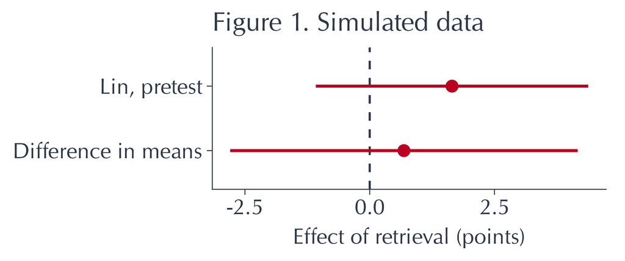

- With the real data, only the input changes. Every reporting decision is made now.
- If the mock figure cannot answer your research question, the real one cannot either.

## Diagnosis: the mock, repeated

- `diagnose_design(design)` reruns the mock on 1,000 simulated data sets.

| Estimator | Power | Bias | Coverage |
| --- | --- | --- | --- |
| Difference in means | 0.30 | -0.03 | 0.94 |
| Lin, pretest | 0.45 | -0.02 | 0.95 |

- Power says whether the sample can detect the effect you assumed.
  - Use this to calibrate your expectations and your design!
- Bias and coverage check that the estimator and interval do what the PAP claims.

## Plans change: amendments, deviations, and SOPs

- A PAP records *when* each decision was made. Later learning is allowed, and labeled as such.
- **Before outcome data:** file a time-stamped amendment.
- **After outcome data:** run the registered analysis, then report the deviation and the reason.
  - The provider retires your pinned model snapshot mid-study.
  - The judge fails on a class of answers you did not foresee.
- **Lin & Green:** a *standard operating procedure* (SOP) sets defaults for situations the PAP did not address.
  - The PAP overrides the SOP.
  - The Green Lab SOP is a public example you can adopt by reference.

[Blair, Coppock & Humphreys (2023), *Research Design in the Social Sciences*, Princeton University Press, chs. 21–22.](https://book.declaredesign.org/lifecycle/planning.html)

[Lin & Green (2016), *Standard Operating Procedures: A Safety Net for Pre-Analysis Plans*, PS: Political Science & Politics 49(3).](https://www.stat.berkeley.edu/~winston/sop-safety-net.pdf)

## After the data: populated PAP and reconciliation

- **Populated PAP:** run the registered code on the real data. Each mock table gets its real numbers.
- **Reconciliation:** list every place the analysis departs from the plan.
  - **Inquiry:** each registered estimand, and whether the report answers it.
  - **Answer strategy:** each planned estimator next to the one reported, with the reason for any change.
- Report both estimates when they differ. The reader decides how much the change matters.
  - Generally keep the complete results in the appendix

Your reconciliation tables become the final report’s “deviations and surprises” section.

[Blair, Coppock & Humphreys (2023), *Research Design in the Social Sciences*, Princeton University Press, ch. 22.](https://book.declaredesign.org/lifecycle/realization.html)

## Summary: what goes in a pre-analysis plan

- A PAP is a public, time-stamped agreement. Contested definitions are settled before anyone knows which answer they favor.
- It declares the whole design: **M**odel, **I**nquiry, **D**ata strategy, **A**nswer strategy.
- `run_design` produces the mock tables and figures. `diagnose_design` reports power, bias, and coverage for each registered estimator.
- Amend before outcome data, document deviations after, and let an SOP cover the unforeseen. The reconciliation tables report every departure.

# Writing your PAP, step by step

## From a design to a registered plan

Your team now writes its own plan and registers it on OSF by **Friday 30 October**.

- What goes in each step?
- How specific is specific enough?

## Ten steps, four graded components

Constructs

- **1.** Research question
- **3.** Construct, outcome, and scoring

Research design

- **2.** Frozen instrument
- **4.** Sampling, sample size, randomization
- **8.** Threats to validity and defenses

Analysis plan

- **5.** Hypotheses
- **6.** Estimator, covariates, standard error
- **7.** Missing data, non-compliance, many tests

Process

- **9.** Mock analysis in a literate notebook
- **10.** Registration and deviation protocol
- Work through the steps in numerical order. Each component is worth 5 of the 20 points.

## Constructs: question, construct, and scoring

- **Step 1, research question:** one sentence naming the system, the comparison, and the population.
  - *Does retrieval over course materials improve tutor answers to questions students in this course ask?*
- **Step 3, construct and scoring:**
  - the construct (answer quality) and why the outcome captures it
  - the scoring rule: rubric, scale, and who or what applies it
  - the judge’s validation against human labels (lecture 04), with its agreement statistic
  - the human-labeled sample used to correct the judge (lecture 06).
- These steps declare the **model** and the **inquiry**.

## Research design: instrument, sample, assignment, threats

- **Step 2, frozen instrument:**
  - model snapshot ids, with the date each was pinned
  - the prompting approach and decoding settings
  - how versions will be recorded when the study runs.
- **Step 4, sampling and assignment:**
  - the question population and how questions are drawn from it
  - sample size from a power calculation
  - the randomization: unit, blocks, and how the seed is fixed.
- **Step 8, threats:** threats from the course, paired with a defense.
  - *Contamination: benchmark questions may be in the training data. Defense: write 40 new questions after the model’s cutoff.*
- These steps declare the **data strategy**.

## Analysis plan: hypotheses, estimator, missing data, many tests

- **Step 5, hypotheses:** one primary hypothesis tied to one estimand. Secondary hypotheses are listed and labeled.
- **Step 6, estimation:**
  - the estimator, with covariates named
  - the standard error and its clustering level
  - the interval, and its small-sample version if needed.
- **Step 7, the unplanned:**
  - a fixed rule for refusals, API errors, and users who stop
  - the retry policy
  - the correction for multiple tests: Holm or Benjamini–Hochberg.
- These steps declare the **answer strategy**.

## Process: mock analysis, registration, deviations

- **Step 9, mock analysis:** a literate notebook that simulates data from your model and produces every planned table and figure.
  - Report power, bias, and coverage from the same simulation.
- **Step 10, registration:**
  - register on OSF by Friday 30 October
  - attach a frozen snapshot of the repository: PAP, harness, analysis code
  - state the deviation protocol: amendments before data, documented deviations after.
- **Process on GitHub:** the PAP steward breaks the plan into issues, assigns them, and reviews the pull requests.

## Vague versus specific

Vague

- We will compare the accuracy of the two Bundles and test whether the difference is significant.
- We will control for relevant covariates.
- We will handle missing data appropriately.

Specific

- **Estimand:** mean score with retrieval minus without, over the 200 sampled questions.
- **Estimator:** Lin, covariates pilot difficulty and topic. CR2 SE clustered on question (5 runs each); $t$ interval.
- **Test:** two-sided, $\alpha=0.05$.
- **Missing:** a refusal or failed call after 3 retries scores 0, analyzed as assigned. Missingness reported by arm.
- Test each item: could two teams follow it independently and get the same number?

## Summary: writing your PAP

- Steps 1 and 3 declare the model and inquiry. Steps 2, 4, and 8 declare the data strategy. Steps 5–7 declare the answer strategy.
- Step 9’s mock notebook produces every planned table and figure, with power, bias, and coverage.
- Step 10 registers the PAP and a frozen repository snapshot on OSF by **Friday 30 October**.
- An item is specific enough when two teams could follow it independently and get the same number.

# Before session 8

## Next week’s readings

- **Blair, Coppock & Humphreys (2023), ch. 21 “Planning”:** how to declare and diagnose the whole design.
- **Lin & Green (2016)** and the **Green Lab SOP:** which defaults to adopt for what the PAP leaves out.
- **Singh et al. (2025), “The Leaderboard Illusion”:** how selective reporting distorts a public ranking.

[Blair, Coppock & Humphreys (2023), *Research Design in the Social Sciences*, Princeton University Press, ch. 21.](https://book.declaredesign.org/lifecycle/planning.html) [Lin & Green (2016), *Standard Operating Procedures: A Safety Net for Pre-Analysis Plans*, PS: Political Science & Politics 49(3).](https://www.stat.berkeley.edu/~winston/sop-safety-net.pdf) [Lin, Green & Coppock (2016), *Standard Operating Procedures for Don Green’s Lab at Columbia*, GitHub.](https://github.com/acoppock/Green-Lab-SOP) [Singh et al. (2025), *The Leaderboard Illusion*, arXiv:2504.20879.](https://arxiv.org/abs/2504.20879)

## Reflection memos and the PAP draft

Reflection memo

- For students writing on next week’s reading.
- One page: what the reading tells you about your team’s evaluation, and what you would change.
- **Post by 26 October**, 24 hours before session 8.
  - I read every memo posted by then and return written comments.

PAP draft

- One per team: a complete draft, brought to session 8.
- In the workshop we discuss the PAPs
  - Teams will be paired and will swap PAPs to comment on them.
- **Final PAP:** registered on OSF by **Friday 30 October**.